# normalizing-flows-cross-feedback

No Inferences, conslusions or comments are present in any questions.

Missing experiments that ran on multiple different conditions/parameters.

Can refer the sample solution and check how to provide necessary comments and conclusions for each question.

Has implemented RealNVP class with all the necessary functions and logics.

training logic is similiar to that of the sample solution, which is good.

Has provided scattered plot for the generated data.

Although, only single training is done, didn't try with multiple different parameters & comparisons.

Hasn't tried implementing the same with GMM.

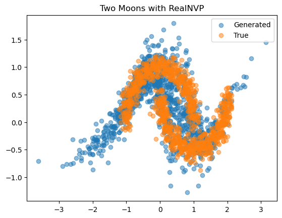

```python
import torch
import torch.nn as nn
import torch.optim as optim
from torch.utils.data import DataLoader, TensorDataset
from sklearn.datasets import make_moons
import matplotlib.pyplot as plt
import numpy as np

#Coupling Block for RealNVP
class CouplingBlock(nn.Module):
    def __init__(self, input_size, hidden_size):
        super(CouplingBlock, self).__init__()
        self.scale_net = nn.Sequential(
            nn.Linear(input_size // 2, hidden_size),
            nn.ReLU(),
            nn.Linear(hidden_size, hidden_size),
            nn.ReLU(),
            nn.Linear(hidden_size, input_size // 2),
            nn.Tanh()
        )
        self.translate_net = nn.Sequential(
            nn.Linear(input_size // 2, hidden_size),
            nn.ReLU(),
            nn.Linear(hidden_size, hidden_size),
            nn.ReLU(),
            nn.Linear(hidden_size, input_size // 2)
        )

    def forward(self, x):
        x1, x2 = torch.chunk(x, 2, dim=1)
        s = self.scale_net(x1)
        t = self.translate_net(x1)
        y1 = x1
        y2 = x2 * torch.exp(s) + t
        return torch.cat([y1, y2], dim=1), s

    def reverse(self, y):
        y1, y2 = torch.chunk(y, 2, dim=1)
        s = self.scale_net(y1)
        t = self.translate_net(y1)
        x1 = y1
        x2 = (y2 - t) * torch.exp(-s)
        return torch.cat([x1, x2], dim=1)

# RealNVP Model
class RealNVP(nn.Module):
    def __init__(self, input_size, hidden_size, blocks):
        super(RealNVP, self).__init__()
        self.blocks = nn.ModuleList([
            CouplingBlock(input_size, hidden_size) for _ in range(blocks)
        ])
        self.input_size = input_size

    def forward(self, x):
        log_det_jacobians = []
        for block in self.blocks:
            x, s = block(x)
            log_det_jacobians.append(s.sum(dim=1))
        return x, sum(log_det_jacobians)

    def reverse(self, y):
        for block in reversed(self.blocks):
            y = block.reverse(y)
        return y

    def sample(self, num_samples):
        z = torch.randn((num_samples, self.input_size))
        return self.reverse(z)

# Training
def train_inn(model, train_loader, epochs=10, lr=0.001):
    optimizer = optim.Adam(model.parameters(), lr=lr)
    for epoch in range(epochs):
        for x_batch in train_loader:
            x_batch = x_batch[0]  # Unpack data loader tuple
            x_batch = x_batch.float()

            z, log_det_jacobian = model(x_batch)
            log_prob = -0.5 * torch.sum(z**2, dim=1) - 0.5 * model.input_size * np.log(2 * np.pi)
            loss = -(log_prob + log_det_jacobian).mean()

            optimizer.zero_grad()
            loss.backward()
            optimizer.step()
        print(f"Epoch {epoch + 1}/{epochs}, Loss: {loss.item():.4f}")

# Dataset
def prepare_data(noise=0.1, n_samples=1000):
    X, _ = make_moons(n_samples=n_samples, noise=noise)
    return DataLoader(TensorDataset(torch.tensor(X)), batch_size=128, shuffle=True)

# Main
if __name__ == "__main__":
    input_size = 2
    hidden_size = 64
    blocks = 4

    train_loader = prepare_data()
    model = RealNVP(input_size=input_size, hidden_size=hidden_size, blocks=blocks)

    train_inn(model, train_loader, epochs=20)

    # Visualize
    generated_data = model.sample(1000).detach().numpy()
    plt.scatter(generated_data[:, 0], generated_data[:, 1], alpha=0.5, label="Generated")
    X, _ = make_moons(n_samples=1000, noise=0.1)
    plt.scatter(X[:, 0], X[:, 1], alpha=0.5, label="True")
    plt.legend()
    plt.title("Two Moons with RealNVP")
    plt.show()
```

@2

Has implemented ConditionalRealNVP class.

Missing the main experiment with GMM where the centers are on the corners of a regular hexagon and its related visualisations

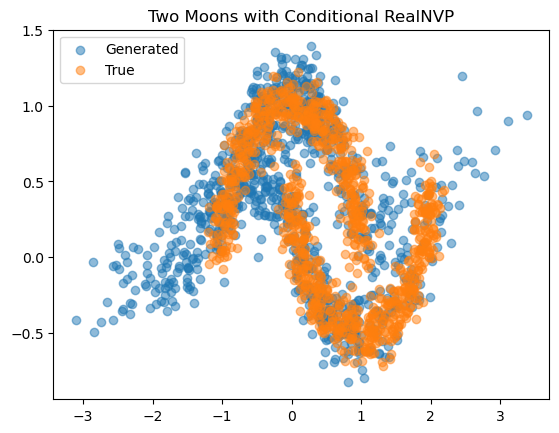

```python
import torch
import torch.nn as nn
import torch.optim as optim
from torch.utils.data import DataLoader, TensorDataset
from sklearn.datasets import make_moons
import matplotlib.pyplot as plt
import numpy as np

#Coupling Block for Conditional RealNVP
class CouplingBlock(nn.Module):
    def __init__(self, input_size, hidden_size, condition_size):
        super(CouplingBlock, self).__init__()
        self.scale_net = nn.Sequential(
            nn.Linear(input_size // 2 + condition_size, hidden_size),
            nn.ReLU(),
            nn.Linear(hidden_size, hidden_size),
            nn.ReLU(),
            nn.Linear(hidden_size, input_size // 2),
            nn.Tanh()
        )
        self.translate_net = nn.Sequential(
            nn.Linear(input_size // 2 + condition_size, hidden_size),
            nn.ReLU(),
            nn.Linear(hidden_size, hidden_size),
            nn.ReLU(),
            nn.Linear(hidden_size, input_size // 2)
        )

    def forward(self, x, condition):
        x1, x2 = torch.chunk(x, 2, dim=1)
        c = condition.expand(x1.size(0), condition.size(1))
        s = self.scale_net(torch.cat([x1, c], dim=1))
        t = self.translate_net(torch.cat([x1, c], dim=1))
        y1 = x1
        y2 = x2 * torch.exp(s) + t
        return torch.cat([y1, y2], dim=1), s

    def reverse(self, y, condition):
        y1, y2 = torch.chunk(y, 2, dim=1)
        c = condition.expand(y1.size(0), condition.size(1))
        s = self.scale_net(torch.cat([y1, c], dim=1))
        t = self.translate_net(torch.cat([y1, c], dim=1))
        x1 = y1
        x2 = (y2 - t) * torch.exp(-s)
        return torch.cat([x1, x2], dim=1)

#Conditional RealNVP Model
class ConditionalRealNVP(nn.Module):
    def __init__(self, input_size, hidden_size, blocks, condition_size):
        super(ConditionalRealNVP, self).__init__()
        self.blocks = nn.ModuleList([
            CouplingBlock(input_size, hidden_size, condition_size) for _ in range(blocks)
        ])
        self.input_size = input_size

    def forward(self, x, condition):
        log_det_jacobians = []
        for block in self.blocks:
            x, s = block(x, condition)
            log_det_jacobians.append(s.sum(dim=1))
        return x, sum(log_det_jacobians)

    def reverse(self, y, condition):
        for block in reversed(self.blocks):
            y = block.reverse(y, condition)
        return y

    def sample(self, num_samples, conditions):
        z = torch.randn((len(conditions) * num_samples, self.input_size))
        c = torch.tensor(conditions).float().repeat_interleave(num_samples, dim=0)
        return self.reverse(z, c)

# Training
def train_conditional_inn(model, train_loader, epochs=10, lr=0.001):
    optimizer = optim.Adam(model.parameters(), lr=lr)
    for epoch in range(epochs):
        for x_batch, c_batch in train_loader:  #the same loader
            x_batch = x_batch.float()
            c_batch = c_batch.float()

            z, log_det_jacobian = model(x_batch, c_batch)
            log_prob = -0.5 * torch.sum(z**2, dim=1) - 0.5 * model.input_size * np.log(2 * np.pi)
            loss = -(log_prob + log_det_jacobian).mean()

            optimizer.zero_grad()
            loss.backward()
            optimizer.step()

        print(f"Epoch {epoch + 1}/{epochs}, Loss: {loss.item():.4f}")

# Dataset preparation
def prepare_conditional_data(noise=0.1, n_samples=1000):
    X, y = make_moons(n_samples=n_samples, noise=noise)
    X = torch.tensor(X).float()
    y = torch.tensor(np.eye(2)[y]).float()  # One-hot encode labels
    dataset = TensorDataset(X, y)
    return DataLoader(dataset, batch_size=128, shuffle=True, drop_last=True)

# Main
if __name__ == "__main__":
    input_size = 2
    hidden_size = 64
    blocks = 4
    condition_size = 2

    train_loader = prepare_conditional_data()

    model = ConditionalRealNVP(input_size=input_size, hidden_size=hidden_size, blocks=blocks, condition_size=condition_size)

    train_conditional_inn(model, train_loader, epochs=20)

    # Visualize
    conditions = [[1, 0], [0, 1]]  # two moons
    generated_data = model.sample(500, conditions).detach().numpy()
    plt.scatter(generated_data[:, 0], generated_data[:, 1], alpha=0.5, label="Generated")
    X, _ = make_moons(n_samples=1000, noise=0.1)
    plt.scatter(X[:, 0], X[:, 1], alpha=0.5, label="True")
    plt.legend()
    plt.title("Two Moons with Conditional RealNVP")
    plt.show()
```

Has implemented RealMVP for higher dimensional data.

Has provided Latent distribution & synthetic generated data visualizations. But missing inferences.

No implmentation of RealMVP with bottleneck parameter & related visualisations and conclusions

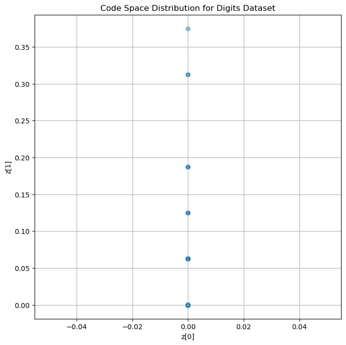

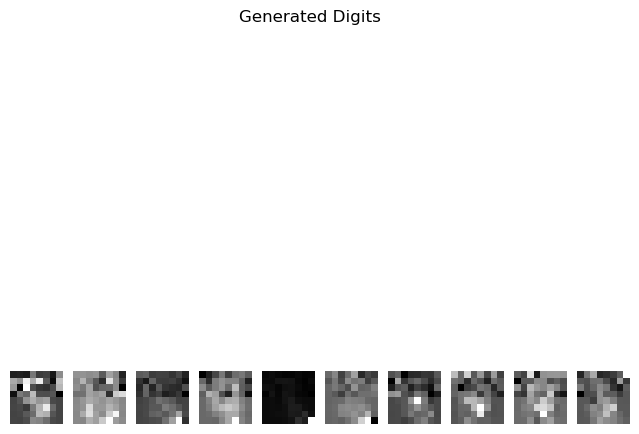

```python
import torch
import torch.nn as nn
import torch.optim as optim
from torch.utils.data import DataLoader, TensorDataset
from sklearn.datasets import load_digits
import matplotlib.pyplot as plt
import numpy as np

#Coupling Block for Higher-dimensional RealNVP
class CouplingBlock(nn.Module):
    def __init__(self, input_size, hidden_size):
        super(CouplingBlock, self).__init__()
        self.scale_net = nn.Sequential(
            nn.Linear(input_size // 2, hidden_size),
            nn.ReLU(),
            nn.Linear(hidden_size, hidden_size),
            nn.ReLU(),
            nn.Linear(hidden_size, input_size // 2),
            nn.Tanh()
        )
        self.translate_net = nn.Sequential(
            nn.Linear(input_size // 2, hidden_size),
            nn.ReLU(),
            nn.Linear(hidden_size, hidden_size),
            nn.ReLU(),
            nn.Linear(hidden_size, input_size // 2)
        )

    def forward(self, x):
        x1, x2 = torch.chunk(x, 2, dim=1)
        s = self.scale_net(x1)
        t = self.translate_net(x1)
        y1 = x1
        y2 = x2 * torch.exp(s) + t
        return torch.cat([y1, y2], dim=1), s

    def reverse(self, y):
        y1, y2 = torch.chunk(y, 2, dim=1)
        s = self.scale_net(y1)
        t = self.translate_net(y1)
        x1 = y1
        x2 = (y2 - t) * torch.exp(-s)
        return torch.cat([x1, x2], dim=1)

# Define the Higher-dimensional RealNVP Model
class RealNVP(nn.Module):
    def __init__(self, input_size, hidden_size, blocks):
        super(RealNVP, self).__init__()
        self.blocks = nn.ModuleList([
            CouplingBlock(input_size, hidden_size) for _ in range(blocks)
        ])
        self.input_size = input_size

    def forward(self, x):
        log_det_jacobians = []
        for block in self.blocks:
            x, s = block(x)
            log_det_jacobians.append(s.sum(dim=1))
        return x, sum(log_det_jacobians)

    def reverse(self, y):
        for block in reversed(self.blocks):
            y = block.reverse(y)
        return y

    def sample(self, num_samples):
        z = torch.randn((num_samples, self.input_size))
        return self.reverse(z)

# Training function
def train_inn(model, train_loader, epochs=10, lr=0.001):
    optimizer = optim.Adam(model.parameters(), lr=lr)
    for epoch in range(epochs):
        for x_batch in train_loader:
            x_batch = x_batch[0]  # Unpack data loader tuple
            x_batch = x_batch.float()

            z, log_det_jacobian = model(x_batch)
            log_prob = -0.5 * torch.sum(z**2, dim=1) - 0.5 * model.input_size * np.log(2 * np.pi)
            loss = -(log_prob + log_det_jacobian).mean()

            optimizer.zero_grad()
            loss.backward()
            optimizer.step()

        print(f"Epoch {epoch + 1}/{epochs}, Loss: {loss.item():.4f}")

# Dataset preparation
def prepare_high_dimensional_data():
    digits = load_digits()
    X = digits.data / 16.0  # Normalize pixel values to [0, 1]
    X = torch.tensor(X).float()
    dataset = TensorDataset(X)
    return DataLoader(dataset, batch_size=128, shuffle=True, drop_last=True)

# Main script
if __name__ == "__main__":
    input_size = 64  # 8x8 images flattened
    hidden_size = 128
    blocks = 6

    train_loader = prepare_high_dimensional_data()

    model = RealNVP(input_size=input_size, hidden_size=hidden_size, blocks=blocks)

    train_inn(model, train_loader, epochs=20)

    # Visualize code space distribution
    data_iter = iter(train_loader)
    x_batch = next(data_iter)[0].float()
    z, _ = model(x_batch)
    z = z.detach().numpy()

    plt.figure(figsize=(8, 8))
    plt.scatter(z[:, 0], z[:, 1], alpha=0.5)
    plt.title("Code Space Distribution for Digits Dataset")
    plt.xlabel("z[0]")
    plt.ylabel("z[1]")
    plt.grid()
    plt.show()

    # Generate synthetic data
    synthetic_data = model.sample(1000).detach().numpy()
    plt.figure(figsize=(8, 8))
    for i in range(10):
        plt.subplot(1, 10, i + 1)
        plt.imshow(synthetic_data[i].reshape(8, 8), cmap='gray')
        plt.axis('off')
    plt.suptitle("Generated Digits")
    plt.show()
```

Has implemented ConditionalRealMVP for higher dimensional data.

Generated visualizations seems to be unclear (digits aren't recognizable).

No Conclusions are present.

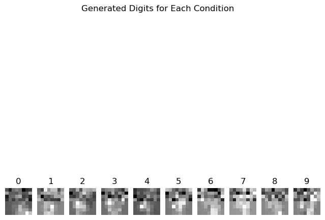

```python
import torch
import torch.nn as nn
import torch.optim as optim
from torch.utils.data import DataLoader, TensorDataset
from sklearn.datasets import load_digits
import matplotlib.pyplot as plt
import numpy as np

#Coupling Block for Conditional RealNVP
class CouplingBlock(nn.Module):
    def __init__(self, input_size, hidden_size, condition_size):
        super(CouplingBlock, self).__init__()
        self.scale_net = nn.Sequential(
            nn.Linear(input_size // 2 + condition_size, hidden_size),
            nn.ReLU(),
            nn.Linear(hidden_size, hidden_size),
            nn.ReLU(),
            nn.Linear(hidden_size, input_size // 2),
            nn.Tanh()
        )
        self.translate_net = nn.Sequential(
            nn.Linear(input_size // 2 + condition_size, hidden_size),
            nn.ReLU(),
            nn.Linear(hidden_size, hidden_size),
            nn.ReLU(),
            nn.Linear(hidden_size, input_size // 2)
        )

    def forward(self, x, condition):
        x1, x2 = torch.chunk(x, 2, dim=1)
        c = condition.expand(x1.size(0), condition.size(1))
        s = self.scale_net(torch.cat([x1, c], dim=1))
        t = self.translate_net(torch.cat([x1, c], dim=1))
        y1 = x1
        y2 = x2 * torch.exp(s) + t
        return torch.cat([y1, y2], dim=1), s

    def reverse(self, y, condition):
        y1, y2 = torch.chunk(y, 2, dim=1)
        c = condition.expand(y1.size(0), condition.size(1))
        s = self.scale_net(torch.cat([y1, c], dim=1))
        t = self.translate_net(torch.cat([y1, c], dim=1))
        x1 = y1
        x2 = (y2 - t) * torch.exp(-s)
        return torch.cat([x1, x2], dim=1)

#Conditional RealNVP Model
class ConditionalRealNVP(nn.Module):
    def __init__(self, input_size, hidden_size, blocks, condition_size):
        super(ConditionalRealNVP, self).__init__()
        self.blocks = nn.ModuleList([
            CouplingBlock(input_size, hidden_size, condition_size) for _ in range(blocks)
        ])
        self.input_size = input_size

    def forward(self, x, condition):
        log_det_jacobians = []
        for block in self.blocks:
            x, s = block(x, condition)
            log_det_jacobians.append(s.sum(dim=1))
        return x, sum(log_det_jacobians)

    def reverse(self, y, condition):
        for block in reversed(self.blocks):
            y = block.reverse(y, condition)
        return y

    def sample(self, num_samples, conditions):
        z = torch.randn((len(conditions) * num_samples, self.input_size))
        c = torch.tensor(conditions).float().repeat_interleave(num_samples, dim=0)
        return self.reverse(z, c)

# Training
def train_conditional_inn(model, train_loader, epochs=10, lr=0.001):
    optimizer = optim.Adam(model.parameters(), lr=lr)
    for epoch in range(epochs):
        for x_batch, c_batch in train_loader:  # Both x and condition come from the same loader
            x_batch = x_batch.float()
            c_batch = c_batch.float()

            z, log_det_jacobian = model(x_batch, c_batch)
            log_prob = -0.5 * torch.sum(z**2, dim=1) - 0.5 * model.input_size * np.log(2 * np.pi)
            loss = -(log_prob + log_det_jacobian).mean()

            optimizer.zero_grad()
            loss.backward()
            optimizer.step()

        print(f"Epoch {epoch + 1}/{epochs}, Loss: {loss.item():.4f}")

# Dataset
def prepare_conditional_high_dimensional_data():
    digits = load_digits()
    X = digits.data / 16.0  # Normalize pixel values to [0, 1]
    y = torch.tensor(digits.target).long()
    y_one_hot = torch.eye(10)[y]  # One-hot encode labels
    X = torch.tensor(X).float()
    dataset = TensorDataset(X, y_one_hot)
    return DataLoader(dataset, batch_size=128, shuffle=True, drop_last=True)

# Main
if __name__ == "__main__":
    input_size = 64  # 8x8 images
    hidden_size = 128
    blocks = 6
    condition_size = 10  # One-hot encoding for 10 digits

    train_loader = prepare_conditional_high_dimensional_data()

    model = ConditionalRealNVP(input_size=input_size, hidden_size=hidden_size, blocks=blocks, condition_size=condition_size)

    train_conditional_inn(model, train_loader, epochs=20)

    # Visualize
    conditions = torch.eye(10)  # One-hot encode digits 0-9
    generated_data = model.sample(10, conditions).detach().numpy()

    plt.figure(figsize=(8, 8))
    for i in range(10):
        plt.subplot(1, 10, i + 1)
        plt.imshow(generated_data[i].reshape(8, 8), cmap='gray')
        plt.title(str(i))
        plt.axis('off')
    plt.suptitle("Generated Digits for Each Condition")
    plt.show()
```

Has implemented RealNVP class using the digit labels as a condition.

No training with RandomForestClassifier.

Generated data isn't recognisable as before.

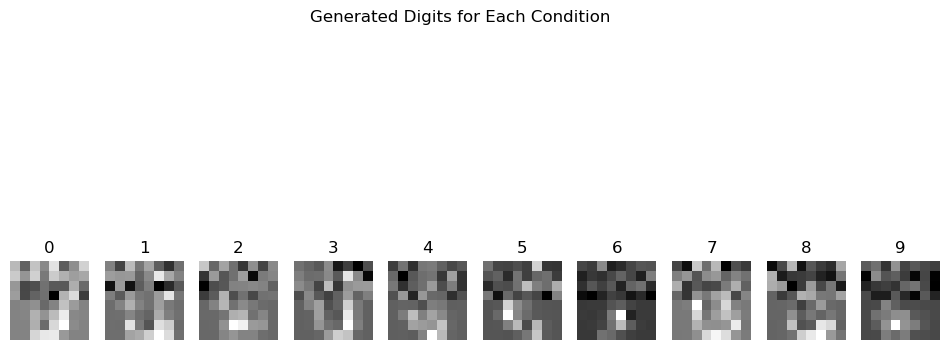

```python
import torch
import torch.nn as nn
import torch.optim as optim
from torch.utils.data import DataLoader, TensorDataset
from sklearn.datasets import load_digits
import matplotlib.pyplot as plt
import numpy as np

#Coupling Block for Conditional RealNVP
class CouplingBlock(nn.Module):
    def __init__(self, input_size, hidden_size, condition_size):
        super(CouplingBlock, self).__init__()
        self.scale_net = nn.Sequential(
            nn.Linear(input_size // 2 + condition_size, hidden_size),
            nn.ReLU(),
            nn.Linear(hidden_size, hidden_size),
            nn.ReLU(),
            nn.Linear(hidden_size, input_size // 2),
            nn.Tanh()
        )
        self.translate_net = nn.Sequential(
            nn.Linear(input_size // 2 + condition_size, hidden_size),
            nn.ReLU(),
            nn.Linear(hidden_size, hidden_size),
            nn.ReLU(),
            nn.Linear(hidden_size, input_size // 2)
        )

    def forward(self, x, condition):
        x1, x2 = torch.chunk(x, 2, dim=1)
        c = condition.expand(x1.size(0), condition.size(1))
        s = self.scale_net(torch.cat([x1, c], dim=1))
        t = self.translate_net(torch.cat([x1, c], dim=1))
        y1 = x1
        y2 = x2 * torch.exp(s) + t
        return torch.cat([y1, y2], dim=1), s

    def reverse(self, y, condition):
        y1, y2 = torch.chunk(y, 2, dim=1)
        c = condition.expand(y1.size(0), condition.size(1))
        s = self.scale_net(torch.cat([y1, c], dim=1))
        t = self.translate_net(torch.cat([y1, c], dim=1))
        x1 = y1
        x2 = (y2 - t) * torch.exp(-s)
        return torch.cat([x1, x2], dim=1)

#Conditional RealNVP Model
class ConditionalRealNVP(nn.Module):
    def __init__(self, input_size, hidden_size, blocks, condition_size):
        super(ConditionalRealNVP, self).__init__()
        self.blocks = nn.ModuleList([
            CouplingBlock(input_size, hidden_size, condition_size) for _ in range(blocks)
        ])
        self.input_size = input_size

    def forward(self, x, condition):
        log_det_jacobians = []
        for block in self.blocks:
            x, s = block(x, condition)
            log_det_jacobians.append(s.sum(dim=1))
        return x, sum(log_det_jacobians)

    def reverse(self, y, condition):
        for block in reversed(self.blocks):
            y = block.reverse(y, condition)
        return y

    def sample(self, num_samples, conditions):
        z = torch.randn((len(conditions) * num_samples, self.input_size)) * 0.5  # Reduce variability in latent space sampling
        c = conditions.clone().detach().float().repeat_interleave(num_samples, dim=0)
        return self.reverse(z, c)

# Training
def train_conditional_inn(model, train_loader, epochs=10, lr=0.001):
    optimizer = optim.Adam(model.parameters(), lr=lr)
    for epoch in range(epochs):
        for x_batch, c_batch in train_loader:  # the same loader
            x_batch = x_batch.float()
            c_batch = c_batch.float()

            z, log_det_jacobian = model(x_batch, c_batch)
            log_prob = -0.5 * torch.sum(z**2, dim=1) - 0.5 * model.input_size * np.log(2 * np.pi)
            loss = -(log_prob + log_det_jacobian).mean()

            optimizer.zero_grad()
            loss.backward()
            optimizer.step()

        print(f"Epoch {epoch + 1}/{epochs}, Loss: {loss.item():.4f}")

# Dataset
def prepare_conditional_high_dimensional_data():
    digits = load_digits()
    X = digits.data / 16.0  # Normalize pixel
    y = torch.tensor(digits.target).long()
    y_one_hot = torch.eye(10)[y]  # One-hot encode labels
    X = torch.tensor(X).float()
    dataset = TensorDataset(X, y_one_hot)
    return DataLoader(dataset, batch_size=128, shuffle=True, drop_last=True)

# Main
if __name__ == "__main__":
    input_size = 64  # 8x8 images
    hidden_size = 256  #for better feature extraction
    blocks = 10  #  deeper network
    condition_size = 10

    train_loader = prepare_conditional_high_dimensional_data()

    model = ConditionalRealNVP(input_size=input_size, hidden_size=hidden_size, blocks=blocks, condition_size=condition_size)

    train_conditional_inn(model, train_loader, epochs=50)  # Extend training epochs for better convergence

    # Visualize
    conditions = torch.eye(10)  # One-hot encode digits 0-9
    generated_data = model.sample(10, conditions).detach().numpy()

    plt.figure(figsize=(12, 6))  #
    for i in range(10):
        plt.subplot(1, 10, i + 1)
        plt.imshow(generated_data[i].reshape(8, 8), cmap='gray')
        plt.title(str(i))
        plt.axis('off')
    plt.suptitle("Generated Digits for Each Condition")
    plt.show()
```